# Determinants of U S College Teacher Salaries

Packages used

```r
library(tidyverse)
library(ggridges)
library(ggthemes)
library(tidyverse)
library(ggpubr)
library(glmnet)
library(caret)
library(lmtest)
```

```r
library(rmarkdown)
library(knitr)
library(tinytex)
library(ggcorrplot)
library(plotmo)
library(MASS)
library(ggfortify)
library(cowplot)
library(SemiPar)
library(dplyr)
```

1 - Cargar los datos. Realizar una inspección por variables de la distribución de salarios en función de cada atributo visualmente. Realizar las observaciones pertinentes. ¿Qué variables son mejores para separar los datos?

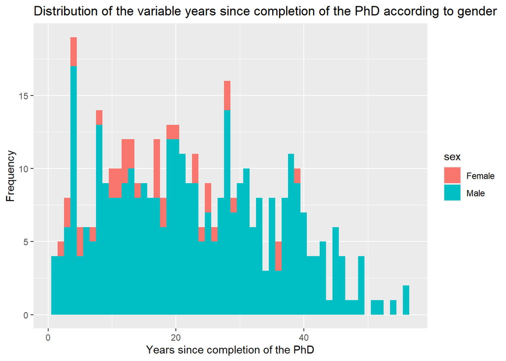

```r
df <- read.csv("Salaries.csv", header = T, sep = ",")

# My first curiosity was to examine the distribution of the variables
#"years of experience" and "years since obtaining a PhD" because I wanted
#to check for the presence of outliers.

# Chart 1

ggplot(df, aes(yrs.since.phd, fill = sex)) +
  geom_histogram(binwidth = 1) +
  labs(

    title = "Distribution of the variable years since completion of the PhD according to gender",
    x = "Years since completion of the PhD",
    y = "Frequency"
  )
```

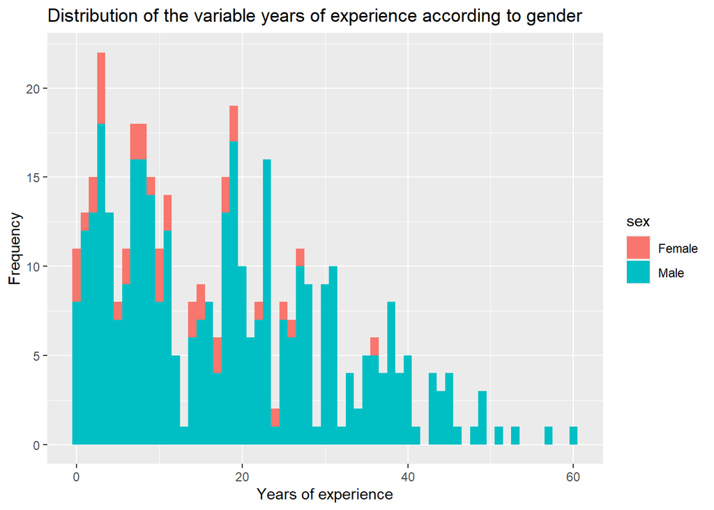

```r
# Chart 2

ggplot(df, aes(yrs.service, fill = sex)) +
  geom_histogram(binwidth = 1) +
  labs(

    title = "Distribution of the variable years of experience according to gender",
    x = "Years of experience",
    y = "Frequency"
  )
```

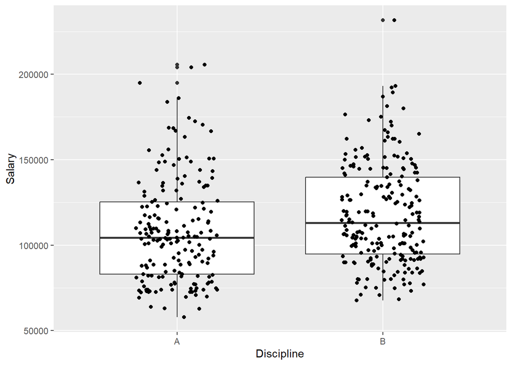

```r
# Chart 3

ggplot(df, aes(x = discipline, y = salary)) +
  geom_boxplot() +
  geom_jitter(shape=16, position=position_jitter(0.2)) +
  labs(

    x = "Discipline",
    y = "Salary"
  )
```

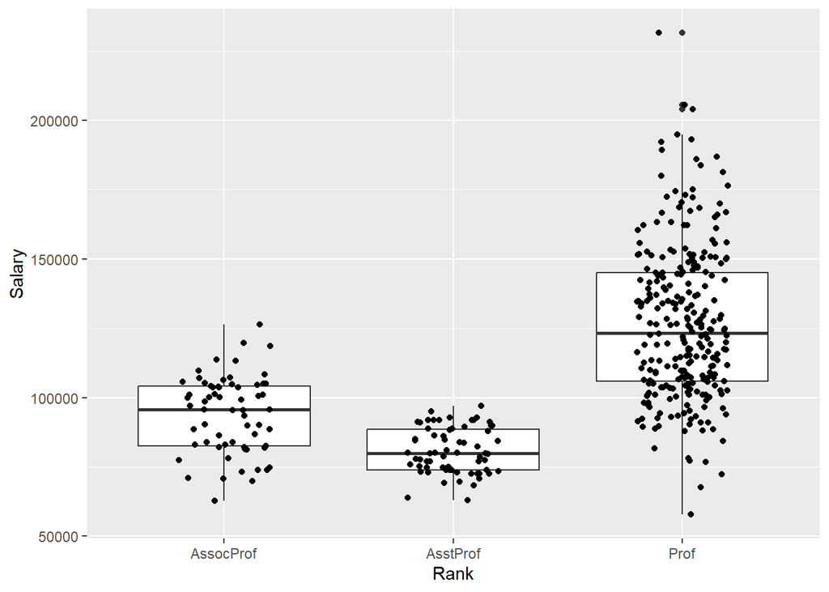

```r
# Chart 4

ggplot(df, aes(x = rank, y = salary)) +
  geom_boxplot() +
  geom_jitter(shape=16, position=position_jitter(0.2)) +
  labs(

    x = "Rank",
    y = "Salary"
  )
```

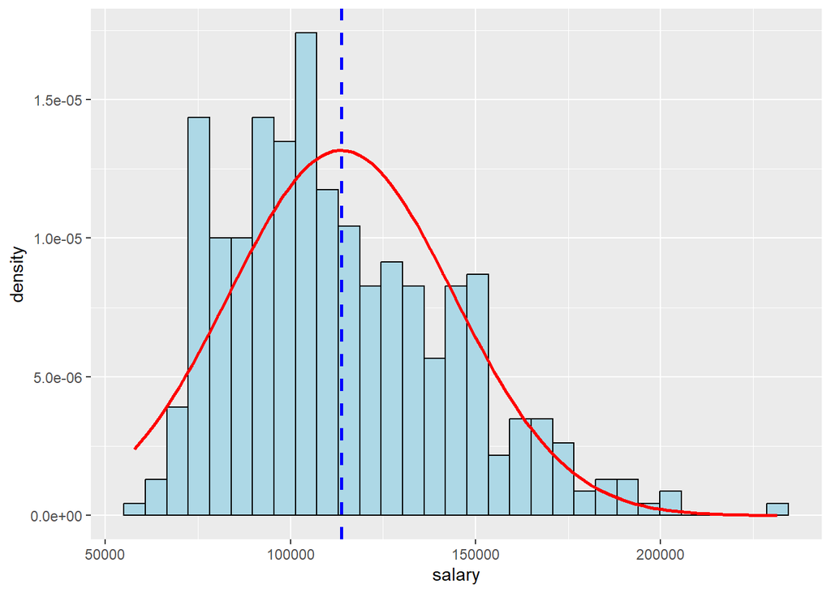

```r
# Then, I examined the distribution of the salary variable to determine whether
#I should apply a transformation before performing the regression analysis.

bw <- (max(df$salary) - min(df$salary)) / 30

ggplot(df, aes(x = salary)) +

  geom_histogram(aes(y = ..density..), colour = "black", binwidth = bw, fill = "lightblue") +

  stat_function(fun = function(x) dnorm(x, mean = mean(df$salary), sd = sd(df$salary)),
                color = "red", size = 1) +

  geom_vline(aes(xintercept = mean(df$salary)), color = "blue", linetype = "dashed", size = 1)
```

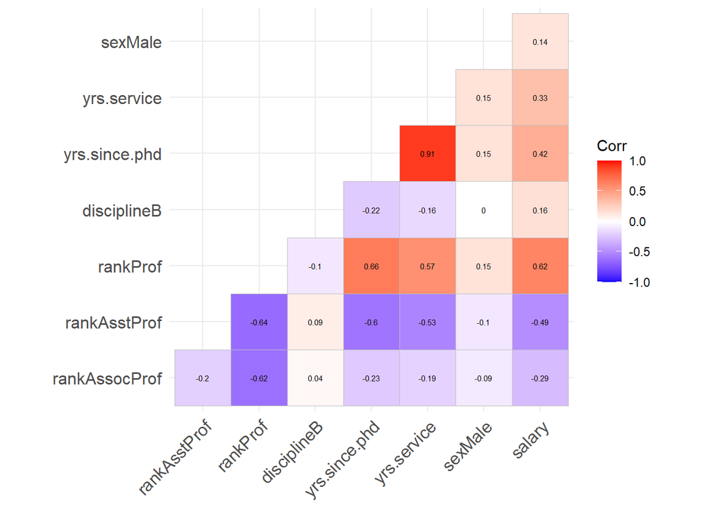

```r
# Correlation matrix

model.matrix(~0+., data=df[, -1]) %>%
  cor(use="pairwise.complete.obs") %>%
  ggcorrplot(show.diag=FALSE, type="lower", lab=TRUE, lab_size=2)
```

The variable “years since obtaining a PhD” is correlated with both “years of experience” and “professor ranking.” Therefore, I choose to remove it from the dataset before performing the linear model. Since the variable “years of service” is right-skewed, I choose to transform it using log + 1. Also, I transformed the variable salary to log.

2 - ¿Se puede emplear un test paramétrico para determinar si las medias de salarios entre hombres y mujeres son las mismas o difieren? Hay que tener que, en tanto que se pide usar un test paramétrico, se deberá determinar si las muestras cumplen con las hipótesis necesarias.

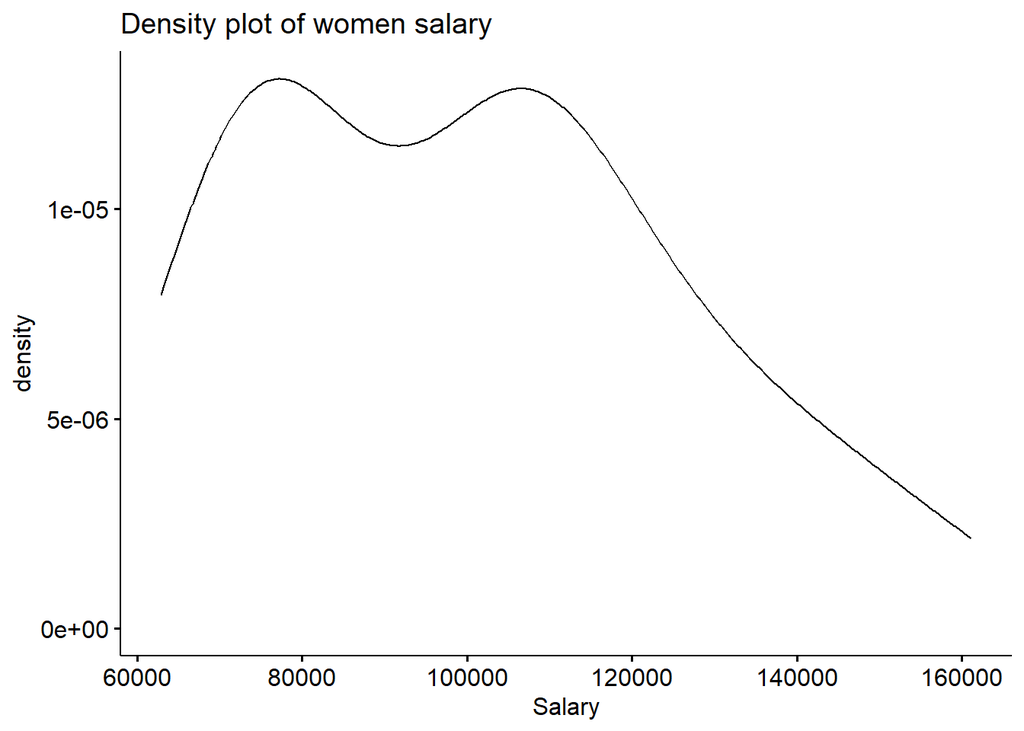

```r
women <- filter(df, sex == "Female")
men <- filter(df, sex == "Male")

ggdensity(women$salary,
          main = "Density plot of women salary",
          xlab = "Salary")
```

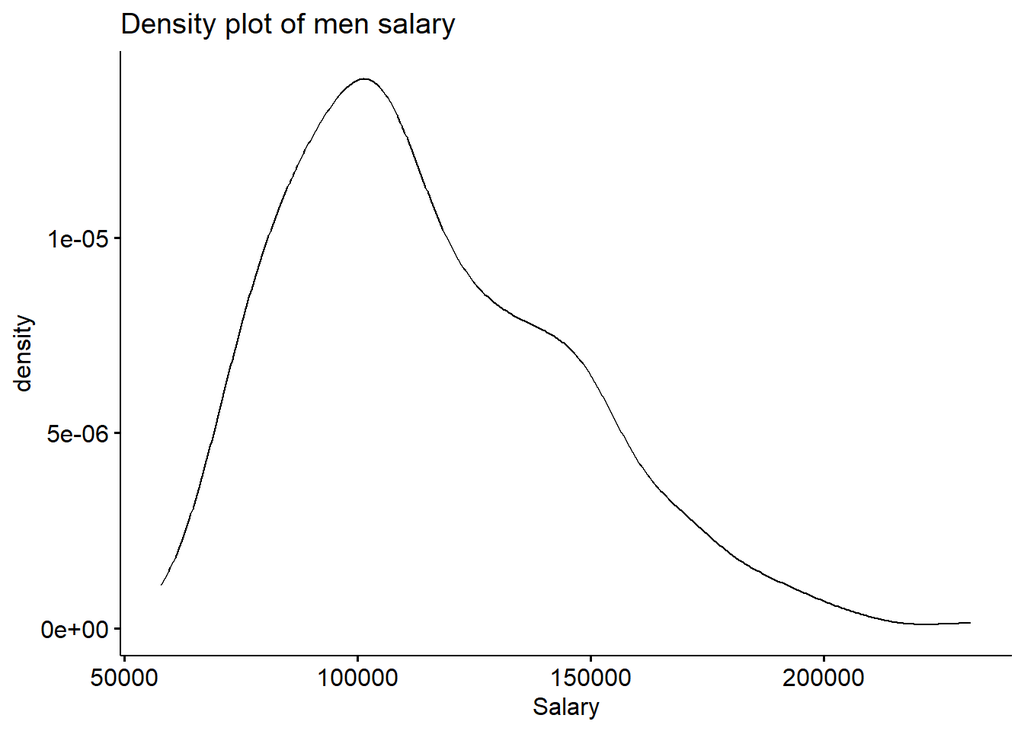

```r
ggdensity(men$salary,
          main = "Density plot of men salary",
          xlab = "Salary")
```

```r
shapiro.test(women$salary)
```

```
##
##  Shapiro-Wilk normality test
##
## data:  women$salary
## W = 0.94665, p-value = 0.06339
```

```r
shapiro.test(men$salary)
```

```
##
##  Shapiro-Wilk normality test
##
## data:  men$salary
## W = 0.95877, p-value = 1.735e-08
```

The salary data for female professors follows a normal distribution, but the data for male professors does not. Nevertheless, since the sample is large, a parametric test can be conducted based on the central limit theorem.

3 - Dividir el dataset tomando las primeras 317 instancias como train y las últimas 80 como test. Entrenar un modelo de regresión lineal con regularización Ridge y Lasso en train seleccionando el que mejor MSE tenga. Dar las métricas en test. Valorar el uso del one hot encoder, y, en caso de emplearlo, argumentarlo.

```r
# Converting yrs.service to log + 1

df <- read.csv("Salaries.csv")

sum(df$yrs.service == 0)
```

```
## [1] 11
```

```r
df <- df |> mutate(yrs.service = ifelse(yrs.service == 0, 0.1, yrs.service))

df <- df |> mutate(yrs.service = log(yrs.service + 1))

summary(df$yrs.service)
```

```
##    Min. 1st Qu.  Median    Mean 3rd Qu.    Max.
## 0.09531 2.07944 2.83321 2.59107 3.33221 4.11087
```

```r
professors <- df |> dplyr::select(-X, -yrs.since.phd)

View(professors)

x = model.matrix(salary~., professors)[,-1]


# Converting salary to log

y <- professors |>
  dplyr::select(salary) |>
  unlist() |>
  as.numeric() |>
  log()


### Ridge model

# Creating many lambda values
grid = 10^seq(10, -2, length = 100)
ridge_mod = glmnet(x, y, alpha = 0, lambda = grid)

dim(coef(ridge_mod))
```

```
## [1]   6 100
```

```r
ridge_mod$call
```

```
## glmnet(x = x, y = y, alpha = 0, lambda = grid)
```

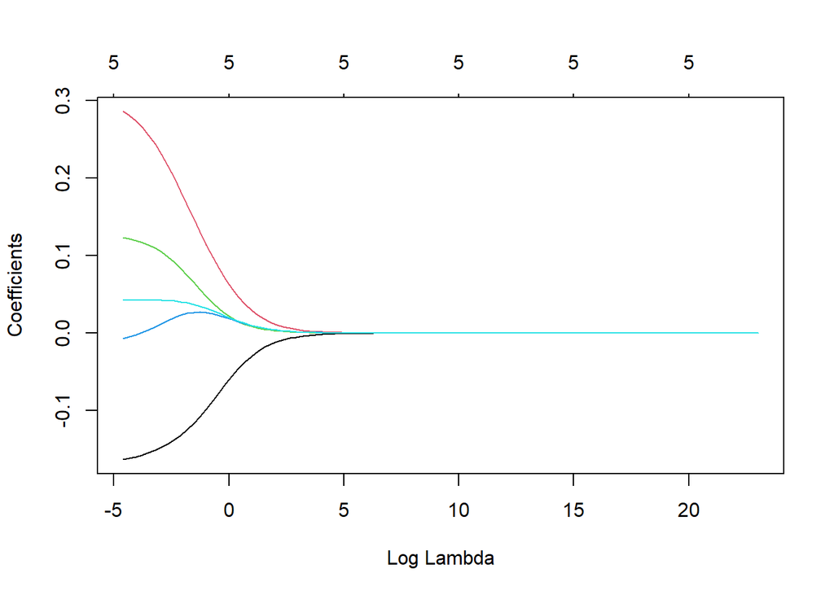

```r
plot(ridge_mod, xvar = "lambda")
```

```r
# Splitting the samples

train <- professors[1:317, ]

test <- tail(professors, 80)

x_train = model.matrix(salary~., train)[,-1]
x_test = model.matrix(salary~., test)[,-1]

y_train = y[1:317]
y_test = tail(y, 80)


# Choosing the best lambda value

set.seed(1)
cv.out = cv.glmnet(x_train, y_train, alpha = 0)
bestlambda = cv.out$lambda.min
bestlambda
```

```
## [1] 0.01712
```

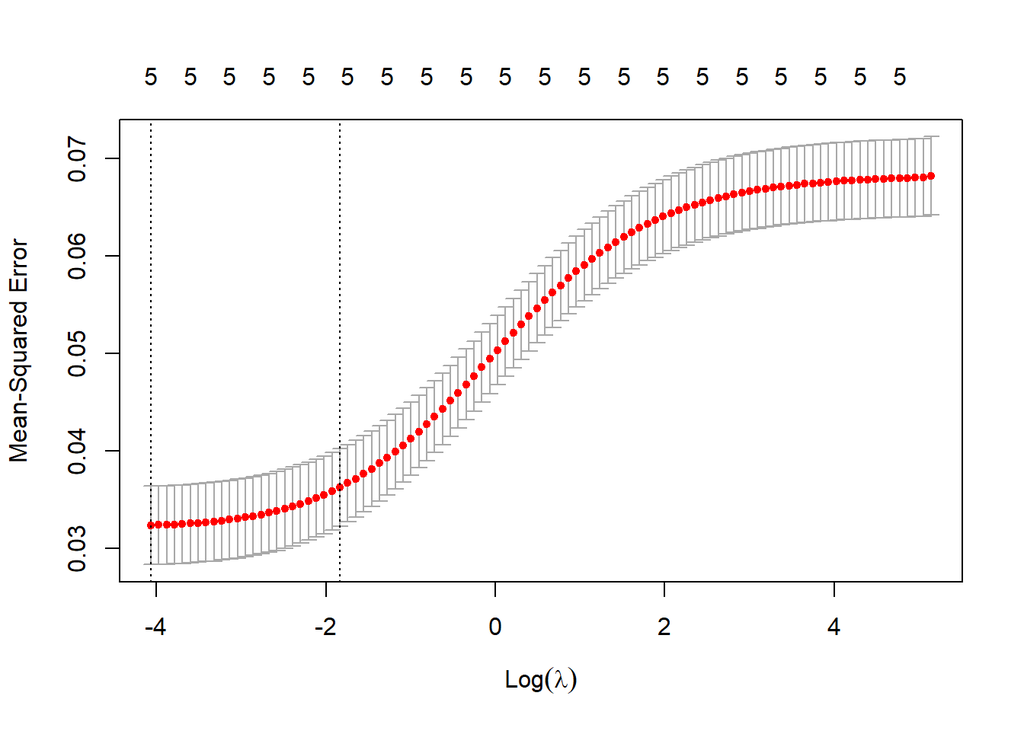

```r
plot(cv.out)
```

```r
# Fitting the model using the best lambda value

ridge_mod = glmnet(x_train, y_train, alpha=0, lambda = grid, thresh = 1e-12)
ridge_pred = predict(ridge_mod, s = bestlambda, newx = x_test)
mean((ridge_pred - y_test)^2)
```

```
## [1] 0.03826848
```

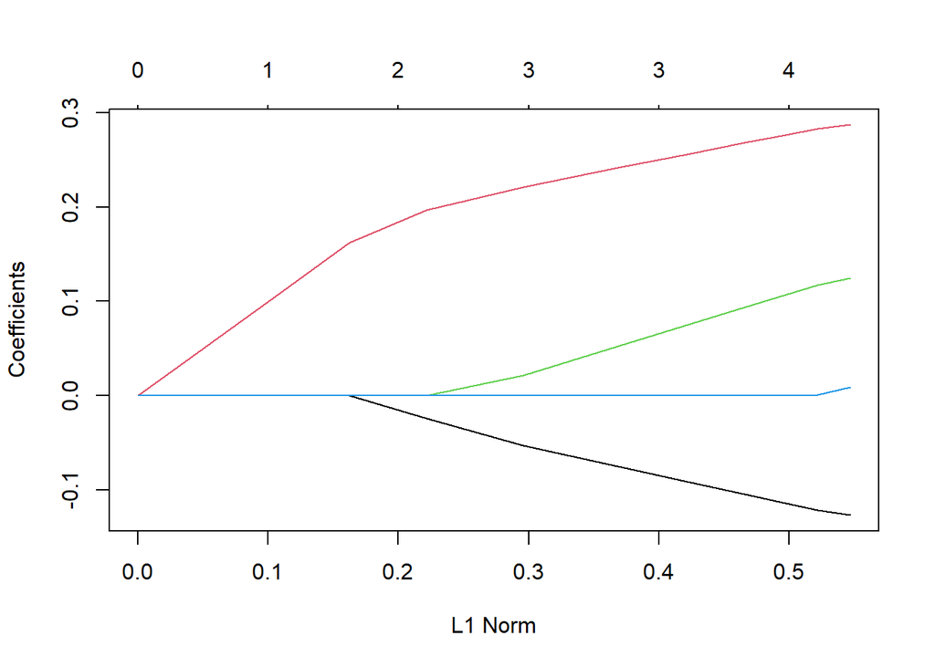

```r
### Lasso model

lasso_mod = glmnet(x_train, y_train, alpha = 1, lambda = grid)

plot(lasso_mod)
```

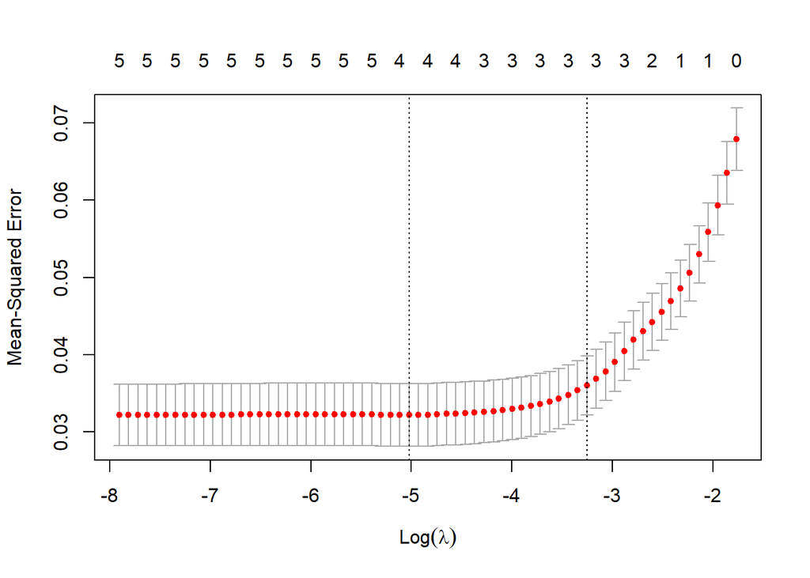

```r
set.seed(1)
cv.out = cv.glmnet(x_train, y_train, alpha = 1)
plot(cv.out)
```

```r
bestlam = cv.out$lambda.min
lasso_pred = predict(lasso_mod, s = bestlam, newx = x_test)
mean((lasso_pred - y_test)^2)
```

```
## [1] 0.03802117
```

The MSE values for both models are very small. Certainly, the prior data preprocessing may have contributed to both models achieving similar performance.

4 - Estudiar la normalidad de los residuos del modelo resultante. ¿Se detecta algún sesgo?

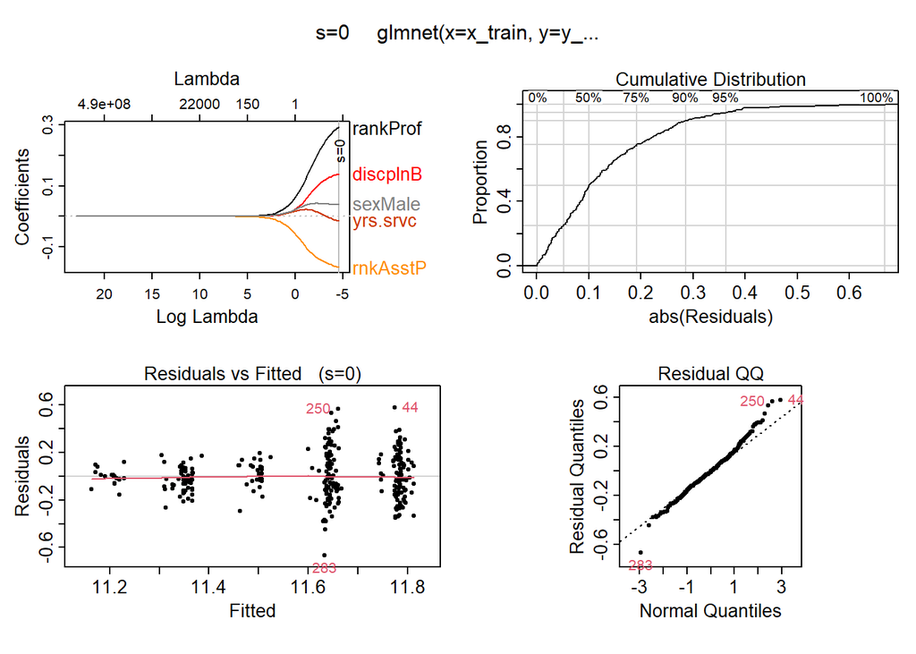

```r
# Ridge model

plotres(ridge_mod)
```

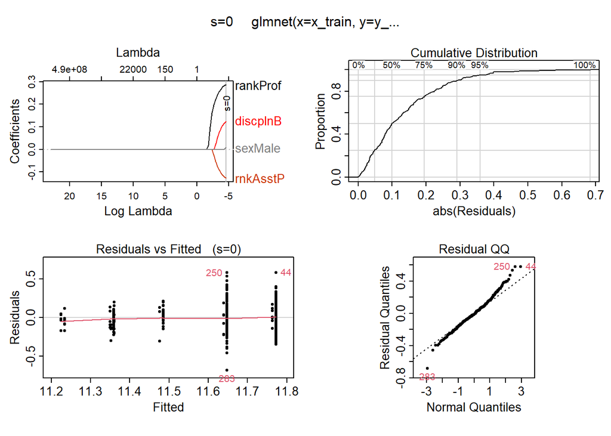

```r
# Lasso model

plotres(lasso_mod)
```

Both models exhibit a good distribution of residuals, although there are some outliers present.However, I do not have enough knowledge about the dataset to suggest that the outliers present indicate measurement errors. Therefore, I choose not to remove them from the dataset.It is possible that we have not captured the full variation in the actual salaries of the professors.

# 5 - ¿Qué conclusiones se extraen de este estudio y del modelo implementado? ¿Es correcto el rendimiento de este?

```r
ridge_coefs <- coef(ridge_mod, s = bestlambda)
ridge_coefs
```

```
## 6 x 1 sparse Matrix of class "dgCMatrix"
##                       s1
## (Intercept)  11.35474751
## rankAsstProf -0.16194491
## rankProf      0.28175657
## disciplineB   0.13422393
## yrs.service  -0.00995514
## sexMale       0.03875393
```

```r
lasso_coefs <- coef(lasso_mod, s = bestlam)
lasso_coefs
```

```
## 6 x 1 sparse Matrix of class "dgCMatrix"
##                        s1
## (Intercept)  11.351756656
## rankAsstProf -0.126527493
## rankProf      0.287045681
## disciplineB   0.124344474
## yrs.service   .
## sexMale       0.009047946
```

```r
# R2 Ridge model

sst <- sum((y_test - mean(y_test))^2)
sse <- sum((y_test - ridge_pred)^2)
r2_ridge <- 1 - (sse/sst)
r2_ridge
```

```
## [1] 0.3711481
```

```r
# R2 Lasso model

sst <- sum((y_test - mean(y_test))^2)
sse_lasso <- sum((y_test - lasso_pred)^2)
r2_lasso <- 1 - (sse_lasso / sst)
r2_lasso
```

```
## [1] 0.375212
```

# Both models explain little of the variation in the salary variable.

The most important variables are the professor’s rank and whether they teach discipline B.